# Otros Gráficos en R

Estadística Descriptiva

10/17/2020

## Diagramas de Dispersión

Los diagramas de dispersión son un tipo de gráfico que son utilizados para mostar la relación entre dos variables numéricas continuas, usando puntos. Cada punto representa la intersección entre los valores de ambas variables.

Por ejemplo, en el siguiente diagrama queremos representar la relación entre la notas en matemáticas y la altura en centímetros de un grupo de estudiantes de un colegio de la ciudad de Cali. Los datos están en la siguiente tabla:

| Altura | Nota en Mate |
| --- | --- |
| 111 | 68 |
| 121 | 62 |
| 177 | 87 |
| 163 | 67 |
| 153 | 91 |
| 144 | 71 |
| 136 | 69 |
| 166 | 59 |
| 167 | 89 |
| 171 | 80 |
| 170 | 78 |
| 164 | 69 |
| 150 | 88 |
| 124 | 59 |

Y usamos la siguiente instrucción `plot` de R para lograr crear nuestro diagrama de dispersión:

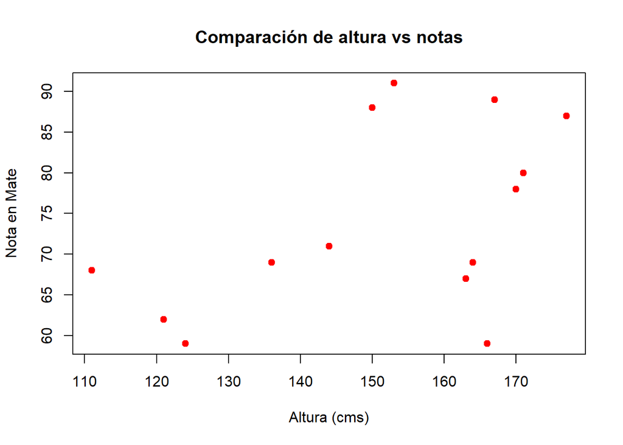

```r
# Guardamos los datos en variables
altura <- c(111, 121, 177, 163, 153, 144, 136, 166, 167, 171, 170, 164, 150, 124)
notas <- c(68, 62, 87, 67, 91, 71, 69, 59, 89, 80, 78, 69, 88, 59)

# Dibujamos el gráfico de dispersión.
plot(altura, notas, main = "Comparación de altura vs notas",
     xlab = "Altura (cms)",
     ylab = "Nota en Mate",
     col = "red",
     pch = 19)
```

También podemos usar los datos de una base de datos o de un archivo local para realizar el gráfico de dispersión. Por ejemplo, el archivo `personas.csv` guarda la información de varias personas. Y queremos ver, utilizando un diagrama de dispersión, la relación entre la edad de esas personas y su peso en kilos.

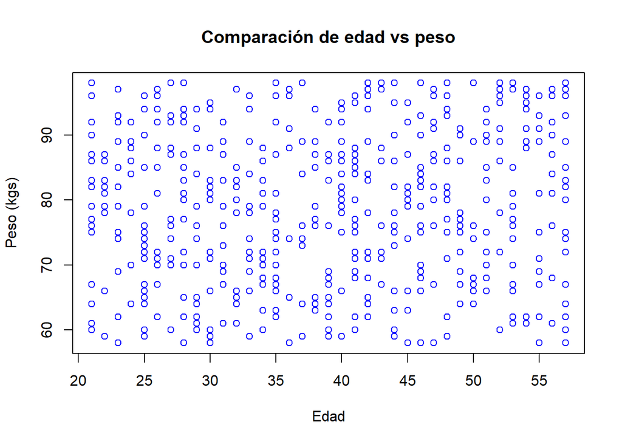

```r
personas <- read.csv("https://raw.githubusercontent.com/luis-cobo/datacampo/master/personas.csv")

plot(personas$edad, personas$peso, main = "Comparación de edad vs peso",
     xlab = "Edad", ylab = "Peso (kgs)", col = "blue")
```

## Gráficos de Araña

También es conocido como gráfico radial, gráfico polar, o parcela de estrellas.

Los gráficos radiales son una manera de comparar múltiples variables cuantitativas. Esto los hace útiles para ver qué variables tienen valores similares o si hay valores extremos entre cada variable. Los gráficos radiales son útiles también para ver de qué variables están resultando altas o bajas dentro de un conjunto de datos, lo que es ideal para la visualización del rendimiento.

Cada variable proporciona un eje que inicia en el centro del diagrama. Todos los ejes están dispuestos radialmente, con distancias iguales entre sí, mientras se mantiene la misma escala entre todos los ejes. Las líneas de la cuadrícula que se conectan de eje a eje, y se utilizan como una guía. Cada valor de la variable se representa a lo largo de su eje individual y todas las variables son un conjunto de datos que conectados entre sí forman un polígono.

Veamos como hacemos en R para presentar un gráfico de araña. Supóngase que tenemos la siguiente tabla donde representamos los promedios finales de las notas de los estudiantes de 5 cursos de un colegio de bachillerato en Dos Quebradas.

| Materia | Promedio |
| --- | --- |
| Física | 77.5 |
| Geografía | 64.2 |
| Historia | 44.3 |
| Filosofía | 91.1 |
| Matemáticas | 89.9 |

Y vamos a presentar esos promedios en un diagrama de araña. Los pasos a seguir son los siguientes:

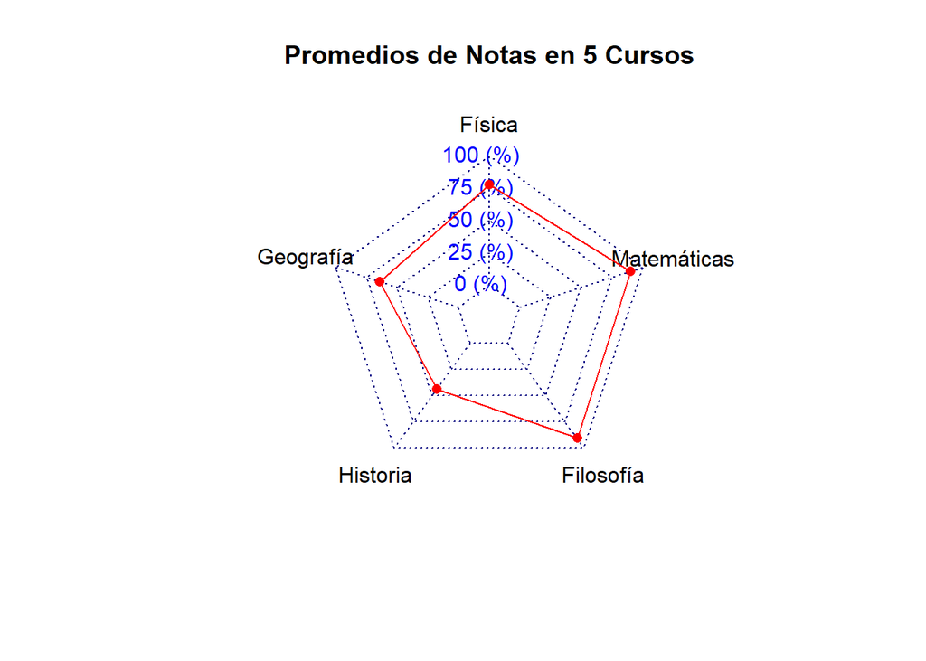

```r
# El paquete que vamos a utilizar es fmsb
library(fmsb)

# Guardamos los datos numéricos en una matriz de una fila y 5 columnas
datos <- as.data.frame(matrix(c(77.5, 64.2, 44.3, 91.1, 89.9), ncol = 5))

# Ahora le colocamos los nombres a cada dato que vamos a graficar
colnames(datos) <- c("Física", "Geografía", "Historia", "Filosofía", "Matemáticas")

# A cada nota le colocamos el máximo y el mínimo
datos <- rbind(rep(100, 5), rep(0, 5), datos)

# Ahora dibujamos el gráfico de araña
radarchart(datos, axistype = 1, pcol = "red", title = "Promedios de Notas en 5 Cursos")
```